# *Chapter 5*

We are working on the Human Development Index data which explores different aspects of human life qualities in different countries. Along with the data also discriminates between genders in order to explore disadvantages/advantages.

We download the data and read it into human.

```
## # A tibble: 155 × 9
##    Country      Edu2.FM Labo.FM Life.Exp Edu.Exp   GNI Mat.Mor Ado.Birth Parli.F
##    <chr>          <dbl>   <dbl>    <dbl>   <dbl> <dbl>   <dbl>     <dbl>   <dbl>
##  1 Norway         1.01    0.891     81.6    17.5 64992       4       7.8    39.6
##  2 Australia      0.997   0.819     82.4    20.2 42261       6      12.1    30.5
##  3 Switzerland    0.983   0.825     83      15.8 56431       6       1.9    28.5
##  4 Denmark        0.989   0.884     80.2    18.7 44025       5       5.1    38
##  5 Netherlands    0.969   0.829     81.6    17.9 45435       6       6.2    36.9
##  6 Germany        0.993   0.807     80.9    16.5 43919       7       3.8    36.9
##  7 Ireland        1.02    0.780     80.9    18.6 39568       9       8.2    19.9
##  8 United Stat…   1.00    0.817     79.1    16.5 52947      28      31      19.4
##  9 Canada         1       0.868     82      15.9 42155      11      14.5    28.2
## 10 New Zealand    0.997   0.840     81.8    19.2 32689       8      25.3    31.4
## # ℹ 145 more rows
```

We need to move the country names to row names show a graphical overview and summaries of this data and interpret it.

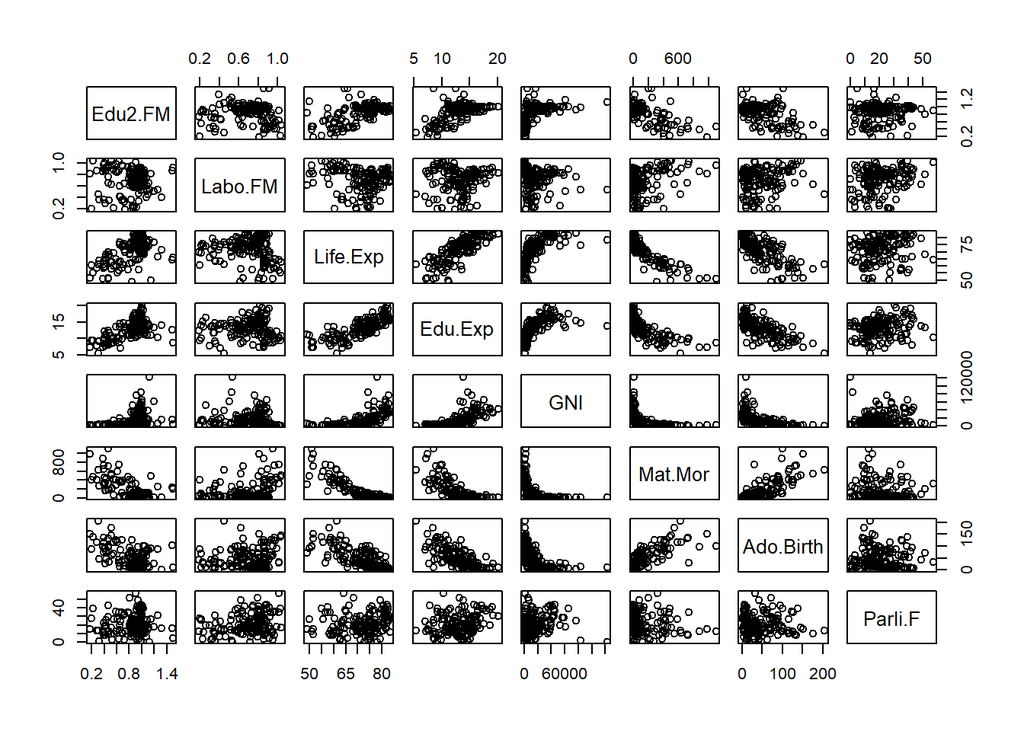

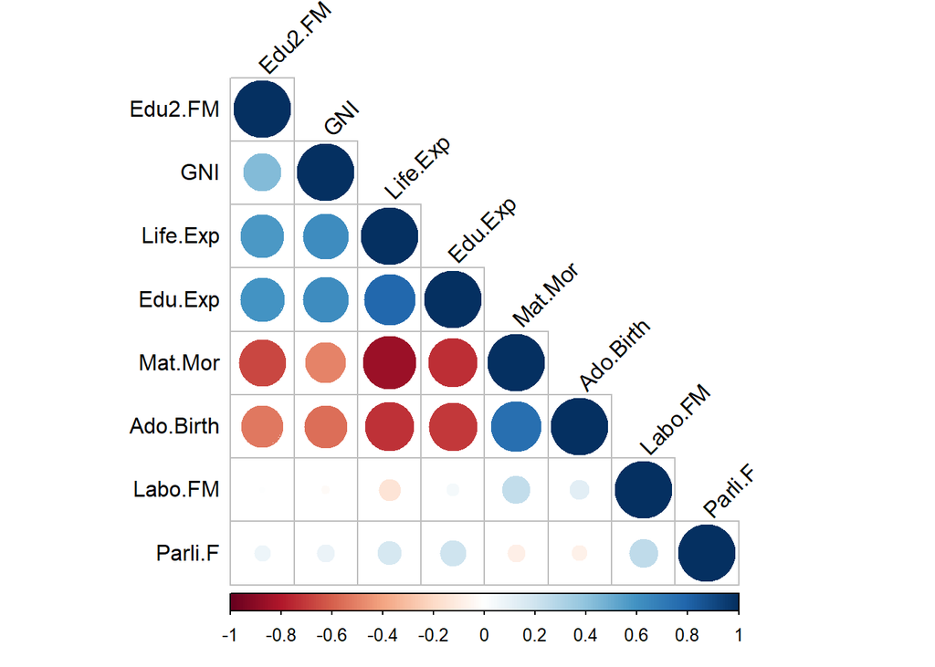

We will need the full names of the variables: “Country” = Country name

Health and knowledge:

“GNI” = Gross National Income per capita “Life.Exp” = Life expectancy at birth “Edu.Exp” = Expected years of schooling “Mat.Mor” = Maternal mortality ratio “Ado.Birth” = Adolescent birth rate

Empowerment:

“Parli.F” = Percetange of female representatives in parliament “Edu2.F” = Proportion of females with at least secondary education “Edu2.M” = Proportion of males with at least secondary education “Labo.F” = Proportion of females in the labour force “Labo.M” ” Proportion of males in the labour force

Overall the correlations seem quite logical. As the higher education and life expectancy relate to higher Gross national income. And these correlate with lower maternal mortalities and adolescent births. Interestingly there is not much connection between female representatives in parliment or female to male ratio in work forces, these seem to be independent of the other factors.

PCA analysis on the non standardized data.

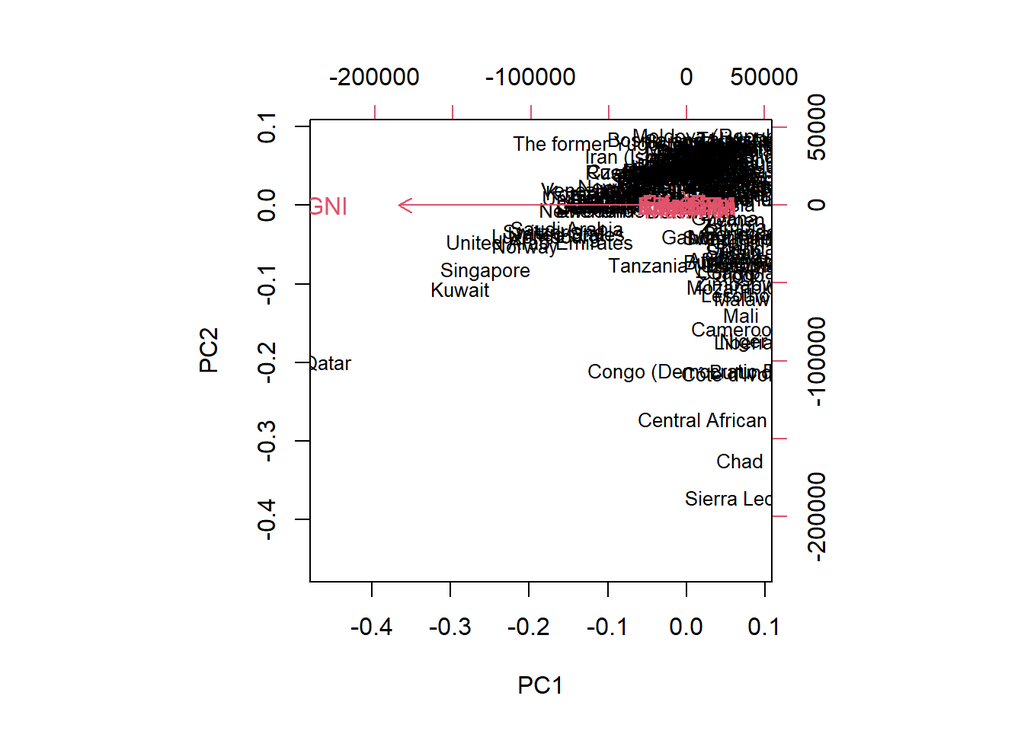

PCA analysis of the standardized data:

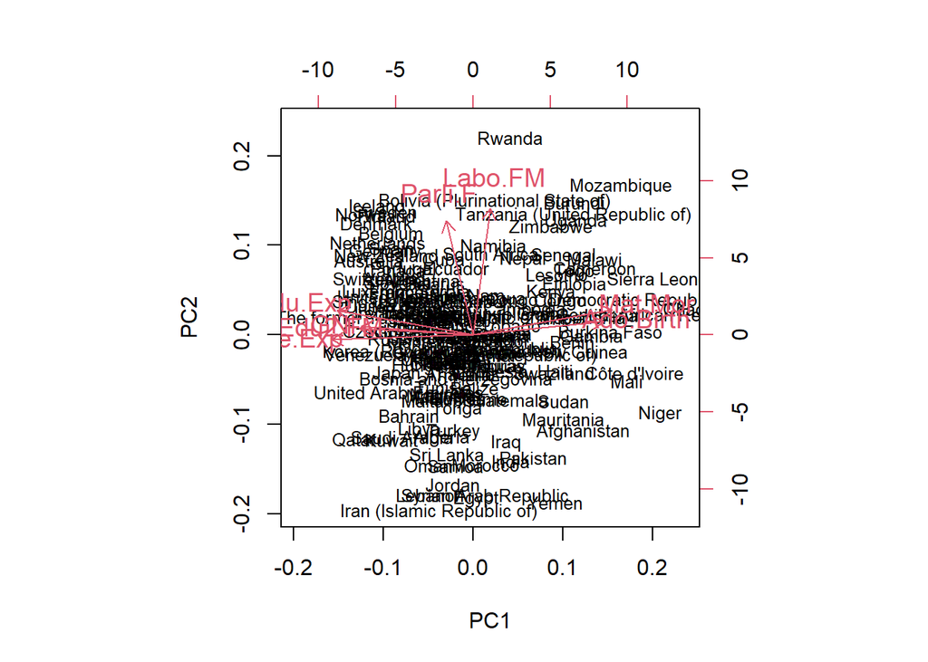

Tea Questionnaire:

```
##         Tea         How           sugar                      where
##  black    : 74   alone:195   No.sugar:155   chain store         :192
##  Earl Grey:193   lemon: 33   sugar   :145   chain store+tea shop: 78
##  green    : 33   milk : 63                  tea shop            : 30
##                  other:  9
##        lunch
##  lunch    : 44
##  Not.lunch:256
##
##
```

```
## 'data.frame':    300 obs. of  5 variables:
##  $ Tea  : Factor w/ 3 levels "black","Earl Grey",..: 1 1 2 2 2 2 2 1 2 1 ...
##  $ How  : Factor w/ 4 levels "alone","lemon",..: 1 3 1 1 1 1 1 3 3 1 ...
##  $ sugar: Factor w/ 2 levels "No.sugar","sugar": 2 1 1 2 1 1 1 1 1 1 ...
##  $ where: Factor w/ 3 levels "chain store",..: 1 1 1 1 1 1 1 1 2 2 ...
##  $ lunch: Factor w/ 2 levels "lunch","Not.lunch": 2 2 2 2 2 2 2 2 2 2 ...
```

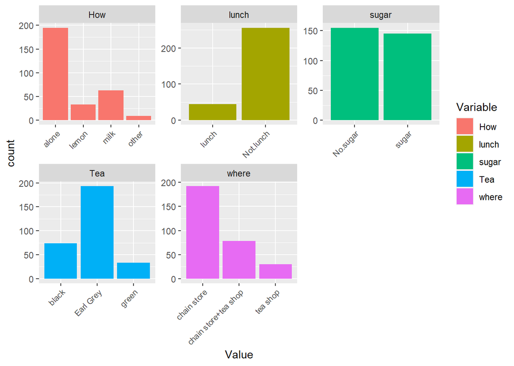

It seems like most people drink their earl grey alone very rarely at lunch. People who prefer their tea with sugar are as many as the ones who prefer it without. Most of the people get their tea from a chain store.

```
##
## Call:
## MCA(X = tea_time, graph = FALSE)
##
##
## Eigenvalues
##                        Dim.1   Dim.2   Dim.3   Dim.4   Dim.5   Dim.6   Dim.7
## Variance               0.268   0.266   0.239   0.214   0.196   0.177   0.167
## % of var.             14.896  14.799  13.295  11.914  10.866   9.807   9.268
## Cumulative % of var.  14.896  29.695  42.990  54.904  65.770  75.578  84.846
##                        Dim.8   Dim.9
## Variance               0.148   0.124
## % of var.              8.244   6.910
## Cumulative % of var.  93.090 100.000
##
## Individuals (the 10 first)
##                Dim.1    ctr   cos2    Dim.2    ctr   cos2    Dim.3    ctr
## 1           | -0.174  0.038  0.028 |  0.214  0.058  0.043 | -0.312  0.136
## 2           |  0.008  0.000  0.000 |  0.670  0.562  0.265 | -0.357  0.177
## 3           | -0.338  0.142  0.206 |  0.024  0.001  0.001 | -0.300  0.125
## 4           | -0.161  0.032  0.045 | -0.452  0.256  0.353 | -0.347  0.168
## 5           | -0.338  0.142  0.206 |  0.024  0.001  0.001 | -0.300  0.125
## 6           | -0.338  0.142  0.206 |  0.024  0.001  0.001 | -0.300  0.125
## 7           | -0.338  0.142  0.206 |  0.024  0.001  0.001 | -0.300  0.125
## 8           |  0.008  0.000  0.000 |  0.670  0.562  0.265 | -0.357  0.177
## 9           |  0.589  0.431  0.209 |  0.183  0.042  0.020 | -0.095  0.012
## 10          |  0.218  0.059  0.031 |  0.869  0.946  0.501 |  0.033  0.002
##               cos2
## 1            0.090 |
## 2            0.075 |
## 3            0.163 |
## 4            0.208 |
## 5            0.163 |
## 6            0.163 |
## 7            0.163 |
## 8            0.075 |
## 9            0.005 |
## 10           0.001 |
##
## Categories (the 10 first)
```

[output cut: 15 more lines]

```
## alone       |  -0.162   1.433   0.049  -3.828 |
## lemon       |   1.811  30.139   0.405  11.007 |
## milk        |  -0.388   2.639   0.040  -3.457 |
## other       |  -0.405   0.412   0.005  -1.233 |
## No.sugar    |   0.056   0.136   0.003   1.002 |
## sugar       |  -0.060   0.145   0.003  -1.002 |
## chain store |  -0.461  11.364   0.378 -10.627 |
##
## Categorical variables (eta2)
##               Dim.1 Dim.2 Dim.3
## Tea         | 0.326 0.528 0.112 |
## How         | 0.442 0.304 0.414 |
## sugar       | 0.052 0.377 0.003 |
## where       | 0.474 0.041 0.663 |
## lunch       | 0.046 0.081 0.004 |
```

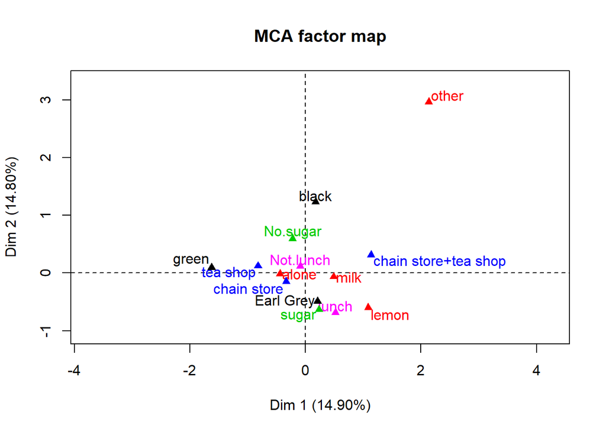